# Midterm

STA 235H

Week of Oct. 16th

# Task 1: Conceptual Questions

**1.1) Thinking about the Minimum Legal Drinking Age (MLDA) example we covered in class, where we were estimating the effect of this policy using a regression discontinuity design, we get the following results:**

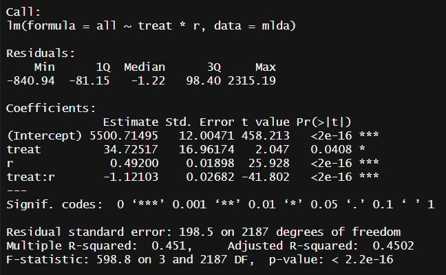

**where `r` represents the centered running variable (age in days, centered around 21 years old), and the treatment variable `treat` takes the value of 1 for those that are legally able to drink and 0 in another case. The outcome `all` represents total number of arrests.**

**Which of the following statements is/are TRUE?** *(4 points)*

1. On average, being legally able to drink increases the total number of arrests by 34.7 compared to not being legally able to drink.
2. For individuals that are not legally able to drink, one additional day in age increases the number of total arrests by 0.49 arrests.
3. The intercept is capturing the average number of arrests for individuals that are exactly 21 years old and are not legally able to drink.
4. On average, being legally able to drink decreases the total number of arrests by 1.12 arrests compared to not being legally able to drink.

*Answer:*

B and C

- A is not correct because this is an effect for individuals that are exactly 21 years old
- D is looking at the interaction, which is the difference in the slopes between the treatment and the control group.

**1.2) The following regression shows a model for salary, education (in years), experience (in years), and gender.**

$$\log(Salary) = \beta_0 +
\beta_1Education + \beta_2 Female + \beta_3 Education \times Female +
\beta_4 Experience + \varepsilon$$
**Where we have the following results:**

$\beta_0$ = 9.62  
$\beta_1$ = 0.03  
$\beta_2$ = -0.06  
$\beta_3$ = 0.01  
$\beta_4$ = 0.02

*(You can assume all coefficients are statistically significant)*

**Keeping this model in mind, which of the following statements is/are FALSE?** *(4 points)*

1. $\beta_0$ is capturing the average salary (in %) for a male individual with 0 years of education and experience.
2. $\beta_4$ is capturing the average change in salary (in %) for one additional year of experience, holding gender and education constant.
3. On average, women have 6% lower salary than men, holding education and experience constant.
4. For one additional year of education, female workers increase their salaries by an average 1% more compared to male workers, holding experience constant.
5. $\beta_1$ captures the average association between $\log(Salary)$ and $Education$ for male workers, holding experience constant.

*Answer:*

A and C

- A is not correct because the intercept is the average log(Salary) – We interpret *changes* in a logarithm as % change.
- B is the correct interpretation for $\beta_4$
- C is not correct because $\beta_2$ captures the average difference in salary between women and men *for individuals with 0 years of education*.
- D is the correct interpretation for $\beta_3$
- E is the correct interpretation for $\beta_1$

**1.3) Which of the following assumptions need to hold in order to estimate a causal effect using a randomized controlled trial?** *(4 points)*

1. Ignorability Assumption
2. SUTVA
3. External Validity
4. Parallel Trend Assumption

*Answer:*

A and B

- External validity is not needed for estimating a causal effect (differnce between internal and external validity).
- Parallel trends is the assumption for DD.

**1.4) The following output shows the results for a regression of homework score on number of hours a student dedicates to a homework, `hrs_hw`, (and number of hours studying squared), the average attendance to class `perc_att` (in a scale of 0 to 100%), and the average number of times a student goes to office hours (`oh_att`).**

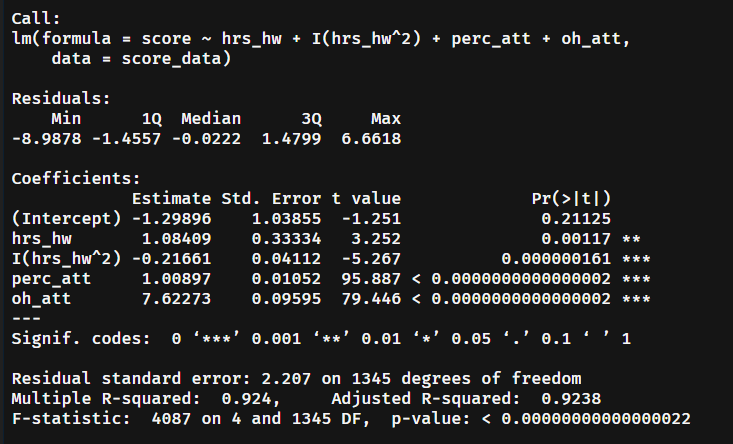

**Which of the following statements is/are TRUE?** *(4 points)*

1. On average, increasing hours dedicated to the homework from 2hr to 3hrs increases the homework score by 0.65 points, holding class attendance and office hour attendance constant.
2. On average, dedicating one additional hour increases homework scores by 1.08 points, holding class attendance and office hour attendance constant.
3. Increasing attendance by 1% is associated with an average increase in homework score of 1.01 points.
4. For a student with the same number of hours dedicated to a homework and the same class attendance, there is a positive association between the number of times a student goes to office hours and their homework score.

*Answer:*

D

- A is not right because we interpret the change as $\beta_1 + 2\times\beta_2\times X_0 = 1.08 - 2\times0.2166\times2 \approx 0.218$.
- B is not correct because the change in score due to one additional hour dedicated to the homework is not constant over the distribution of homework hours (depends on what’s the starting point)
- C is missing “holding other variables constant”.

**1.5) Which of the following do not represent examples of natural experiments?** *(4 points)*

1. Using the Get Out The Vote (GOTV) experiment to analyze the effect of information on voting.
2. Using the Oregon Health Experiment to study the effect of health insurance on labor outcomes.
3. Studying the effect of charter schools vs traditional public schools using the lottery of admission for oversubscribed charter schools.
4. Leveraging the PSAT cutoff for assignment of the Certificate of Merit to estimate the effect of this certificate on scholarships.

*Answer:*

- A was an RCT
- C is and RDD

# Task 2: Stars and Campaigns

In this exercise, we will use data from a large make-up company that is trying to decide how to invest their budget on social media ads. Currently, they have two media campaigns options with two highly recognized figures: Billie Eilish and Ariana Grande. They have hired you to run the data analysis in this case and design the study to determine which campaign would be more successful.

You can find the data here:

```r
campaign = read.csv("https://raw.githubusercontent.com/mbennettstats/mt/main/campaign.csv")
```

Description of variables:

- `ad`: Whether the user was randomized to the Billie Eilish ad (`Billie`) or Ariana Grande (`Ariana`).
- `time`: Time (sec) the user spends watching the ad (if `time = 0`, you can assume the user skip the ad and didn’t see it at all).
- `gender`: Reported gender of the user.
- `age`: Reported age of the user (in years).
- `usage`: Average phone usage (in hrs/day).
- `click`: Whether the person clicks on the ad to go to the company’s website (1) or not (0).

You have decided to run an RCT on TikTok, where some users will be randomized to get the Billie Eilish ad and others the Ariana Grande one. You are interested in clicks as an outcome, because that will determine the effectiveness of the campaign.

**2.1) Create a treatment variable (`treat`) that takes the value of 1 if the individual is randomized to receive the Ariana Grande campaign and 0 in another case. How many observations do you have in the treatment group? And the control group?** *(2 points)*

*Answer:*

```r
campaign = campaign %>% mutate(treat = ifelse(ad == "Ariana", 1, 0))
```

2499 obs in the treatment group

2501 obs in the control group

**2.2) Let’s check for balance! Create an appropriate balance table to ensure that randomization was done correctly. Include your code and table here:** *(6 points)*

*(Use 2 decimal points for your table)*

```r
campaign = campaign %>% mutate(female = ifelse(gender == "Female", 1, 0))

campaign_bal = campaign %>% select(treat, female, age, usage)

datasummary_balance(~ treat, data = campaign_bal, fmt = 2, dinm_statistic = "p.value")
```

|  | 0 Mean | 0 Std. Dev. | 1 Mean | 1 Std. Dev. | Diff. in Means | p |
| --- | --- | --- | --- | --- | --- | --- |
| female | 0.50 | 0.50 | 0.51 | 0.50 | 0.01 | 0.50 |
| age | 21.82 | 2.39 | 21.84 | 2.36 | 0.01 | 0.84 |
| usage | 5.39 | 2.60 | 5.40 | 2.66 | 0.01 | 0.89 |

2 points for changing gender to binary

2 points for correct variables (i.e. not including ad, time, or click)

2 points for balance table with p-values and 2 decimal places (-1 discount if wrong decimals).

**2.3) Are your groups balanced?** *(2 points)*

1. Yes, all variables are balanced.
2. No, some variables are not balanced.

*Answer:*

A

**2.4) Run a simple regression between the treatment and the outcome. Interpret your causal estimate.** *(6 points)*

*Answer:*

```r
options(scipen = 0)

lm_rct = lm_robust(click ~ treat, data = campaign)

summary(lm_rct)
```

```
##
## Call:
## lm_robust(formula = click ~ treat, data = campaign)
##
## Standard error type:  HC2
##
## Coefficients:
##             Estimate Std. Error t value   Pr(>|t|) CI Lower CI Upper   DF
## (Intercept)   0.3735   0.009674   38.60 1.515e-285   0.3545   0.3924 4998
## treat        -0.1310   0.012928  -10.13  6.937e-24  -0.1563  -0.1056 4998
##
## Multiple R-squared:  0.02011 ,   Adjusted R-squared:  0.01992
## F-statistic: 102.6 on 1 and 4998 DF,  p-value: < 2.2e-16
```

On average, being assigned the Ariana Grande ad decreased the probability of clicking the ad by 13.1 percentage points, compared to being assigned the Billie Eilish ad.

1 point for “on average”

2 points for comparison between Ariana vs Billie (needs to mention both specifically)

1 point for correct estimate

1 point for correct units (i.e. percentage points or probability)

1 point for correct outcome interpretation (probability of clicking/ rate of clicks)

**2.5) If we ran the same experiment, but now in YouTube instead of TikTok. Should we expect to have the same results? Why?** *(5 points)*

*Answer:*

We shouldn’t expect to have the same effect as the one estimated for TikTok, because populations are different (e.g. YouTube viewers are probably older) and we can’t necessarily generalize these results.

2 points for identifying that results wouldn’t be the same.

2 points for mentioning that populations are different/ external validity (confounding is not a reason).

1 point for an example of how populations are different (e.g. age).

**2.6) Create a new dataset called `campaign_w` that only considers users that watched at least some of the ads. Create a new balance table like in 2.2) but using the new dataset `campaign_w` as a starting point. Show your code here:** *(6 points)*

*(Use 2 decimal points for your table)*

```r
campaign_w = campaign %>% filter(time > 0)

campaign_w_bal = campaign_w %>% select(treat, female, age, usage)

datasummary_balance(~ treat, data = campaign_w_bal, fmt = 2, dinm_statistic = "p.value")
```

|  | 0 Mean | 0 Std. Dev. | 1 Mean | 1 Std. Dev. | Diff. in Means | p |
| --- | --- | --- | --- | --- | --- | --- |
| female | 0.60 | 0.49 | 0.67 | 0.47 | 0.07 | <0.01 |
| age | 21.89 | 2.38 | 21.84 | 2.32 | -0.04 | 0.65 |
| usage | 5.32 | 2.60 | 5.42 | 2.70 | 0.10 | 0.37 |

1 point for correct dataset (code included or values are correct).

1 point for correct variable female or similar (not including gender as a character variable).

2 points for correct variables (i.e. not including ad, time, or click).

2 points for balance table with p-values and 2 decimal places (-1 discount if wrong decimals).

**2.7) Are your groups balanced?** *(2 points)*

1. Yes, all variables are balanced.
2. No, some variables are not balanced.

*Answer:*

B

**2.8) Using propensity score matching, match both groups in the `campaign_w` dataset using users’ characteristics. Use a caliper of 0.2. Show your code here:** *(5 points)*

*(Hint: Remember that you should match on what you think are potential confounders)*

*Answer:*

```r
m_ad = matchit(treat ~ age + gender + usage,
                data = campaign_w, method = "nearest", caliper = 0.2)

campaign_match = match.data(m_ad)
```

2 point for correct formula (correct outcome and correct variables)

1 point for correct caliper

2 points for correct dataset and method (-1 discount if matching exactly by a variable).

**2.9) Using your matched dataset, estimate the difference in means between both groups. Interpret the appropriate coefficient.** *(6 points)*

*Answer:*

```r
lm_match = lm_robust(click ~ treat, data = campaign_match)

summary(lm_match)
```

```
##
## Call:
## lm_robust(formula = click ~ treat, data = campaign_match)
##
## Standard error type:  HC2
##
## Coefficients:
##             Estimate Std. Error t value  Pr(>|t|) CI Lower CI Upper   DF
## (Intercept)   0.7130    0.01343   53.10 0.000e+00   0.6867   0.7394 2270
## treat        -0.1937    0.02001   -9.68 9.545e-22  -0.2329  -0.1544 2270
##
## Multiple R-squared:  0.03965 ,   Adjusted R-squared:  0.03922
## F-statistic: 93.71 on 1 and 2270 DF,  p-value: < 2.2e-16
```

On average, being assigned the Ariana Grande ad decreased the probability of clicking the ad by 19.4 percentage points, compared to being assigned the Billie Eilish ad, in our matched sample.

1 point for “on average”

2 points for comparison between Ariana vs Billie (needs to mention both specifically)

1 point for correct estimate

1 point for correct units (i.e. percentage points or probability)

1 point for saying “in the matched sample” or similar.

**2.10) Using the previous analysis and tables you have created, why do you think there is a difference between the matched estimate and the RCT estimate? Select all that apply** *(6 points)*

1. The population that watched the ad is different from the original sample of the study.
2. There could be other confounders that we are not adjusting for in the new sample (`campaign_w`)
3. Randomization was not done correctly in the RCT.
4. We could have spillover effects that are biasing our estimates.

*Answer:*

A and B

- A: The population watching the ads is not the same as the total population (e.g. women were more likely to watch the ads), so we shouldn’t expect the effect tot be the same.
- B: Because we are relying on the CIA, it could be that there are other confounders that would bias our estimate.
- C: We don’t have evidence that randomization wasn’t done correctly (groups were balanced).
- D: Even if spillovers were an issue, they would have been an issue in the RCT estimate as well, so that wouldn’t be the reason both estimates are different.

# Task 3: Won’t you be my neighbor?

Subsidies for affordable housing are an important policy in the context of increasing rent and housing costs in the US. Both the US Department of Housing and Urban Development, as well as state and local governments, have engaged in these interventions to provide affordable living spaces.

However, it is often a concern that affordable housing projects could also drive housing prices down in neighborhoods where these are built. For example:

- If individuals prefer to live close to high-income families, affordable housing projects might make the neighborhood less attractive.
- Housing projects could increase the population in a neighborhood, increasing congestion and negatively affecting nearby housing prices.

In this task, we will use a housing dataset from NY to test **whether affordable housing projects reduce property values**. We will be looking at two neighborhoods, one near an affordable housing project (`Neighborhood 2`) and one far from a subsidized housing site (`Neighborhood 1`). You can find the dataset here:

```r
housing = read.csv("https://raw.githubusercontent.com/mbennettstats/mt/main/l/taskl.csv")
```

Description of the variables in the dataset:

- `neighborhood`: Neighborhood 1 or Neighborhood 2.
- `area`: Area of the property, in sqft.
- `bedrooms`: Number of bedrooms in the property.
- `pool`: Whether the property has access to a pool (1) or not (0).
- `date`: Date for the recorded price (`Sep 2018` or `Sep 2019`).
- `price`: Sale price (in dollars) of the property on a given date (see `date`).

In this case, the affordable housing project was built in May 2019. You can assume that before this date, Neighborhood 2 was not close to a housing project.

*Note that we are following the same properties in two periods, so their characteristics (e.g. area, bedrooms, and pool) do not change over time.*

**3.1) Create a `treat` variable that takes the value of 1 for the neighborhood that is close to the housing project and 0 for the one that is far. How many treated observations do you have in your dataset?** *(2 points)*

*Answer:*

```r
housing = housing %>% mutate(treat = ifelse(neighborhood == "Neighborhood 2", 1, 0))

housing %>% count(treat)
```

| treat | n |
| --- | --- |
| 0 | 1040 |
| 1 | 1424 |

1424 observations

**3.2) Create a `post` variable that takes the value of 1 for the date after the affordable housing project was built, and 0 in another case. How many observations in the post-intervention period do you have?** *(2 points)*

*Answer:*

```r
housing = housing %>% mutate(post = ifelse(date == "Sep 2019", 1, 0))

housing %>% count(post)
```

| post | n |
| --- | --- |
| 0 | 1232 |
| 1 | 1232 |

1232 observations

**3.3) Create a balance table between the treated and the control neighborhood to compare the characteristics *before* the project was built (you will need to create a new dataset for this). Include in your table all housing characteristics in addition to price. Show your table here:** *(5 points)*

*(Use 2 decimal places for your table)*

*Answer:*

```r
housing_bal = housing %>% filter(post == 0) %>% select(treat, area, bedrooms, pool, price)

datasummary_balance(~ treat, data = housing_bal, fmt = 2, dinm_statistic = "p.value")
```

|  | 0 Mean | 0 Std. Dev. | 1 Mean | 1 Std. Dev. | Diff. in Means | p |
| --- | --- | --- | --- | --- | --- | --- |
| area | 2258.18 | 123.33 | 1559.75 | 161.30 | -698.43 | <0.01 |
| bedrooms | 2.25 | 0.62 | 1.28 | 0.58 | -0.97 | <0.01 |
| pool | 0.20 | 0.40 | 0.04 | 0.20 | -0.16 | <0.01 |
| price | 590894.92 | 111967.34 | 486683.51 | 112793.47 | -104211.41 | <0.01 |

2 point for correct dataset (code included/values are correct).

2 points for correct variables (i.e. not including neighborhoold or date in the table).

2 points for balance table with p-values and 2 decimal places (-1 discount if wrong decimals).

**3.4) Looking at your previous results (table in 3.3). Which of the following statements is/are TRUE?** *(4 points)*

1. There is a difference of -698.43 sqft in the property area of the treatment group compared to the control group.
2. In the pre-intervention period, both groups appear to be balanced.
3. On average, housing is more expensive in Neighborhood 2 compared to Neighborhood 1 in September 2018.
4. Properties in Neighborhood 1 have, on average, more rooms than properties in Neighborhood 2.

*Answer:*

A and D

**3.5) Given that you are trying to estimate the effect of the project construction on housing prices, a friend suggests that you compare prices between both neighborhoods in September 2019, adding housing characteristics as controls. You don’t think this will give you a causal estimate because you might still have confounding. Which of the following statements would be TRUE about confounding in this case?** *(4 points)*

1. We could not recover a causal estimate, because properties in the treatment group are smaller than in the control group, and that affects housing prices.
2. Neighborhoods with higher income families are less likely to have a project nearby and are also more likely to have amenities such as parks that drive prices up.
3. Because we are not controlling for amenities such as a basement, which affect housing prices, we will not be able to recover a causal estimate.

*Answer:*

B

- A confounder has to affect both the probability of treatment and the outcome (C is unlikely to affect prob of treatment, and A is an observed confounder).

**3.6a) Fit the appropriate difference-in-differences model for this scenario. Show your code here:** *(4 points)*

*Answer:*

```r
options(scipen = 999)

lm_dd = lm(price ~ treat*post, data = housing)

summary(lm_dd)
```

```
##
## Call:
## lm(formula = price ~ treat * post, data = housing)
##
## Residuals:
##     Min      1Q  Median      3Q     Max
## -267442  -80173   -2128   76883  388438
##
## Coefficients:
##             Estimate Std. Error t value             Pr(>|t|)
## (Intercept)   590895       4962 119.096 < 0.0000000000000002 ***
## treat        -104211       6526 -15.967 < 0.0000000000000002 ***
## post           36155       7017   5.153          0.000000277 ***
## treat:post    -46884       9230  -5.080          0.000000407 ***
## ---
## Signif. codes:  0 '***' 0.001 '**' 0.01 '*' 0.05 '.' 0.1 ' ' 1
##
## Residual standard error: 113100 on 2460 degrees of freedom
## Multiple R-squared:  0.2442, Adjusted R-squared:  0.2433
## F-statistic:   265 on 3 and 2460 DF,  p-value: < 0.00000000000000022
```

1 point for correct outcome.

1 point for correct dataframe.

2 points for correct variables (i.e. interaction and nothing else).

**3.6b) What is your causal estimate in this case?** *(Approximate your answer to the closest integer)* *(4 points)*

*Answer:*

-46884

**3.6c) Interpret the previous coefficient.** *(6 points)*

*Answer:*

On average, having a housing project built nearby reduced housing prices in Neighborhood 2 by $46884 compared to not having a project built close by.

6 points: Comparison between having a project close by vs not having a project close by, mentioning that it’s an effect for Neighborhood 2, and saying it’s average effect (in $).

4 points: Comparison between having a project close by vs not having a project close by, and saying it’s average effect (in $) (Not mentioning it’s an effect for Neighborhood 2)

4 points: For saying is an effect on neighborhood 2, and saying it’s average effect (in $) (Not mentioning the comparison b/w having a project nearby vs not)

3 points: Comparison between Neighborhood 2 and Neighborhood 1, and saying it’s average effect (in $)

2 points: Effect of having a project nearby (without the contrast), and saying it’s average effect (in $)

1 point: “On average” (without any other of the items)